# Does Education Buy Free Time? Education Gradients in Personal Well-Being Time Across India

Dr Preet Deep Singh[^1]

November 16, 2025

**JEL Classification:** I26, J16, J22, I31, I14

**Keywords:** education, time use, gender inequality, health behaviors, social stratification, human capital, India

# 1 Introduction

Does education buy free time? Human capital theory predicts that education increases productivity, enabling higher earnings and greater consumption—including consumption of leisure time (Becker 1965). Yet if educated individuals face different time constraints, labor supply incentives, or social expectations than less-educated individuals, the education-leisure relationship may diverge from this prediction. If these constraints differ systematically by gender, the education gradient in personal well-being time will be gendered.

We examine this question using India’s 2024 Time Use Survey, analyzing how education affects time spent on personal well-being activities—socializing, exercise, hobbies, cultural activities, and recreation. Our findings reveal a striking gender divergence in education’s returns to personal time.

The education gradient is **steepest for exercise time**: highly-educated men spend **2.9x more time** on physical exercise than less-educated men. Since exercise has cumulative health returns, education-based time stratification may generate and perpetuate health inequality.

## 1.2 Contributions

**Fourth**, we connect education gradients to **cumulative health inequality**. Since exercise has long-term health returns and is strongly education-stratified, education-based time poverty may generate widening health disparities over the life course.

# 2 Literature Review

## 2.1 Education and Quality of Life

Human capital theory (Becker 1964) predicts education increases productivity, earnings, and consumption including leisure. Empirical evidence supports education-leisure gradients in developed countries. Aguiar and Hurst (2007) document that more-educated Americans have more leisure time despite working longer hours, attributing this to efficiency in household production. Gimenez-Nadal and Sevilla (2012) find similar patterns in Spain and the UK.

However, most studies focus on total leisure time, not health-promoting activities specifically. Cutler and Lleras-Muney (2010) show education predicts health behaviors like exercise, smoking cessation, and preventive care—suggesting education gradients in well-being time may have long-term health consequences.

## 2.2 Gender, Education, and Time Use

Research on gendered returns to education focuses primarily on labor market outcomes. Goldin (2006) documents the gender pay gap narrows with education, while Blau and Kahn (2017) show returns to education differ by gender and family status. However, few studies examine education’s effects on non-market time use.

For India specifically, Chatterjee et al. (2018) show educated women have higher labor force participation but also face greater household work burdens when employed—suggesting education may increase total work rather than leisure. Desai and Andrist (2010) document that educated Indian women face similar mobility restrictions and domestic responsibilities as less-educated women when married.

## 2.3 Health Behaviors and Social Stratification

Link and Phelan (1995) propose that socioeconomic status operates as a “fundamental cause” of health inequality because high-SES individuals use resources to avoid health risks across changing contexts. Education may facilitate health-promoting time use through: (1) knowledge of health benefits, (2) financial resources to access facilities, (3) neighborhoods with safe exercise spaces, and (4) social norms privileging fitness.

Pampel et al. (2010) show education gradients in health behaviors have widened over time in developed countries. For developing countries, Cutler et al. (2015) document emerging education-health gradients in India, China, and Africa as health knowledge diffuses first to educated populations.

## 2.4 Marriage, Location, and Time Constraints

Marriage affects time allocation differently by gender. Married women perform more household work than single women while married men perform less than single men (Bianchi et al. 2000). If marriage imposes time constraints that overwhelm education’s benefits, we would observe conditional education effects.

Geographic location matters for leisure infrastructure. Urban areas provide parks, gyms, cultural venues that facilitate personal well-being activities. If education’s returns depend on accessing this infrastructure, urban-rural divides will condition education effects.

# 3 Data and Methods

## 3.2 Measuring Personal Well-Being Time

- **Exercise time** (codes 831-832): Physical exercise, sports
- **Social time** (codes 711-719): Visiting friends, socializing
- **Cultural time** (codes 821-829): Arts, hobbies, entertainment

## 3.3 Education Measurement

We use three education measures:

1. **Three-category classification**: Primary or less, Secondary, Higher Secondary+ (for descriptive analysis)
2. **Binary higher education indicator**: Higher Secondary+ vs. below (for regressions)
3. **Years of education**: Imputed from education categories (for gradient analysis)

## 3.4 Analytical Approach

We estimate education effects using weighted linear regression:

$$\text{WellbeingHours}_{i} = \beta_0 +
\beta_1 \text{EducationYears}_i + \beta_2 \text{Female}_i + \beta_3
(\text{Education} \times \text{Female})_i + \mathbf{X}_i'\gamma +
\epsilon_i$$

where $\mathbf{X}_i$ includes age, age-squared, marital status, urban location, employment status, and state fixed effects. The interaction $\beta_3$ captures differential education returns by gender.

To examine conditioning factors, we estimate:

$$\text{WellbeingHours}_{i} = \beta_0 +
\beta_1 \text{Education}_i + \beta_2 \text{Married}_i + \beta_3
\text{Urban}_i + \beta_4 (\text{Ed} \times \text{Married})_i + \beta_5
(\text{Ed} \times \text{Urban})_i + \mathbf{X}_i'\gamma +
\epsilon_i$$

separately for men and women.

**Standard errors** are clustered at the household level. **Survey weights** ensure national representativeness.

# 4 Results

## 4.1 Descriptive Patterns

Table 1 presents mean daily personal well-being time by education and gender.

Personal Well-Being Time by Education and Gender (hours/day)

[output not shown]

**Men’s Monotonic Gradient**: Personal time increases monotonically with education for men: 0.45 hours (primary or less) → 0.50 hours (higher secondary+), a 9% increase.

**Women’s Flat Gradient**: Women show a much weaker gradient: 0.42 hours (primary or less) → 0.43 hours (higher secondary+), only a 4% increase.

**Widening Gender Gap**: The gender gap in personal time widens with education, from minimal at low education levels to substantial at high education levels.

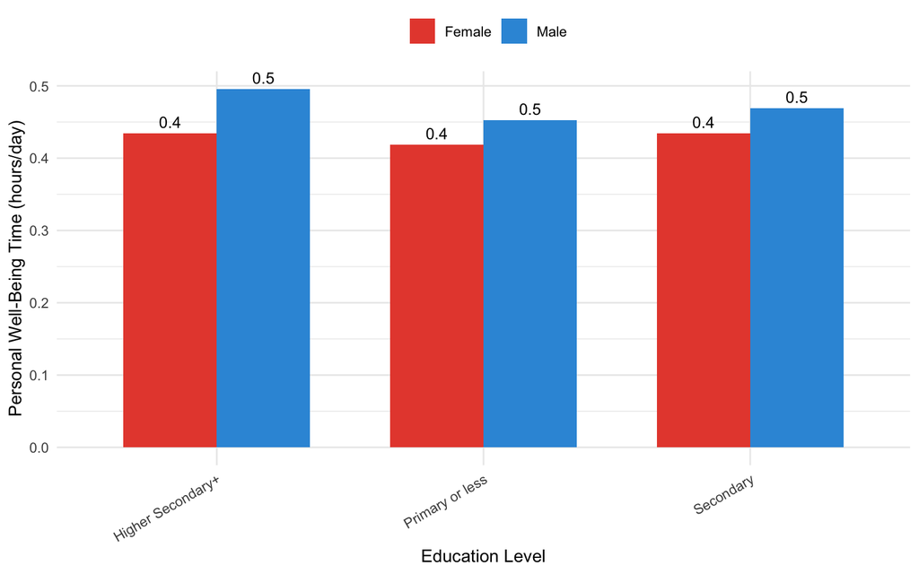

Education Gradient in Personal Time Differs Sharply by Gender

## 4.2 Regression Analysis

Table 2 presents regression estimates.

Education Gradient in Personal Well-Being Time

|  | &nbsp;(1) | &nbsp;&nbsp;(2) | &nbsp;&nbsp;(3) | &nbsp;&nbsp;(4) |
| --- | --- | --- | --- | --- |
| education_years | 0.002*** | 0.003*** | 0.004*** | 0.002*** |
|  | (0.000) | (0.000) | (0.000) | (0.000) |
| female | −0.039*** | −0.025*** | −0.024*** | −0.168*** |
|  | (0.003) | (0.006) | (0.006) | (0.007) |
| education_years × female |  | −0.002*** | −0.002*** | 0.001** |
|  |  | (0.001) | (0.001) | (0.001) |
| married |  |  |  | −0.073*** |
|  |  |  |  | (0.005) |
| urban |  |  |  | −0.004 |
|  |  |  |  | (0.004) |
| employed |  |  |  | −0.201*** |
|  |  |  |  | (0.005) |
| Num.Obs. | 271285 | 271285 | 271285 | 271285 |
| R2 | 0.001 | 0.001 | 0.006 | 0.017 |

* p < 0.1, ** p < 0.05, *** p < 0.01  
Dependent variable: Daily hours of personal well-being time.  
Education measured in years (0-18).  
Standard errors (in parentheses) clustered at household level.  
All models use survey weights adjusted for 10% sampling.

## 4.3 Heterogeneity: Women’s Conditional Returns

Table 3 examines how marriage and urban location condition women’s education returns.

Women’s Personal Time by Education, Marriage, and Location (hours/day)

| education_level | N | Married_Rural | Married_Urban | Not Married_Rural | Not Married_Urban |
| --- | --- | --- | --- | --- | --- |
| Higher Secondary+ | 5149.00 | 0.41 | NA | NA | NA |
| Higher Secondary+ | 10307.00 | NA | 0.42 | NA | NA |
| Higher Secondary+ | 2467.00 | NA | NA | 0.51 | NA |
| Higher Secondary+ | 4052.00 | NA | NA | NA | 0.46 |
| Primary or less | 37390.00 | 0.39 | NA | NA | NA |
| Primary or less | 10910.00 | NA | 0.47 | NA | NA |
| Primary or less | 5945.00 | NA | NA | 0.46 | NA |
| Primary or less | 2791.00 | NA | NA | NA | 0.52 |
| Secondary | 29736.00 | 0.41 | NA | NA | NA |
| Secondary | 18812.00 | NA | 0.46 | NA | NA |
| Secondary | 7631.00 | NA | NA | 0.48 | NA |
| Secondary | 5674.00 | NA | NA | NA | 0.48 |

## 4.4 Activity-Specific Gradients

Table 4 shows education gradients differ by activity type.

Education Gradients by Activity Type (hours/day)

| education_level | Exercise_Female | Exercise_Male | Social_Female | Social_Male |
| --- | --- | --- | --- | --- |
| Higher Secondary+ | 0.010 | 0.031 | 0.113 | 0.146 |
| Primary or less | 0.003 | 0.011 | 0.166 | 0.179 |
| Secondary | 0.004 | 0.017 | 0.138 | 0.154 |

**Exercise shows the steepest gradient**: Highly-educated men spend 2.9x more time on exercise than less-educated men. This education stratification in health behaviors has long-term cumulative health consequences.

# 5 Discussion

## 5.1 Why Does Education’s Return to Personal Time Differ by Gender?

We propose three mechanisms:

**1. Time Constraints from Unpaid Work**: Education increases men’s earnings and bargaining power, enabling them to “buy” personal time. For women, education increases labor force participation but does not reduce unpaid household work—generating a time squeeze that offsets any gains.

**2. Marriage Norms Override Education**: In contexts with strong patriarchal norms (rural areas, conservative communities), marriage imposes time constraints on women regardless of education. Educated rural married women face the same domestic expectations as less-educated women.

## 5.2 Implications

**For Health Inequality**: Education-stratified exercise time generates cumulative health advantages for educated men. Since health compounds over the life course, education-based time poverty may widen health inequality.

**For Gender Equality**: Policies promoting women’s education will not equalize time poverty unless they also address marriage norms and rural infrastructure deficits.

**For Human Capital Theory**: Returns to education are gendered and conditional, not universal. Education increases men’s quality of life but not necessarily women’s.

## 5.3 Limitations

**Cross-sectional design**: We observe associations. Educated individuals may have different preferences for personal time.

**Single-day observation**: Time diaries capture one day. Multi-day diaries would improve measurement.

**Omitted mechanisms**: We lack data on household bargaining, detailed time constraints, or access to infrastructure.

# 6 Conclusion

The steepest education gradient appears in exercise time—a health behavior with cumulative long-term returns. Education-based stratification in personal time thus generates and perpetuates health inequality across the life course.

# References

Aguiar, Mark, and Erik Hurst. 2007. “Measuring Trends in Leisure: The Allocation of Time over Five Decades.” *Quarterly Journal of Economics* 122(3): 969-1006.

Becker, Gary S. 1964. *Human Capital: A Theoretical and Empirical Analysis*. New York: Columbia University Press.

Becker, Gary S. 1965. “A Theory of the Allocation of Time.” *Economic Journal* 75(299): 493-517.

Bianchi, Suzanne M., Melissa A. Milkie, Liana C. Sayer, and John P. Robinson. 2000. “Is Anyone Doing the Housework? Trends in the Gender Division of Household Labor.” *Social Forces* 79(1): 191-228.

Blau, Francine D., and Lawrence M. Kahn. 2017. “The Gender Wage Gap: Extent, Trends, and Explanations.” *Journal of Economic Literature* 55(3): 789-865.

Chatterjee, Urmila, Rinku Murgai, and Martin Rama. 2018. “Job Opportunities along the Rural-Urban Gradation and Female Labor Force Participation in India.” World Bank Policy Research Working Paper 8400.

Cutler, David M., and Adriana Lleras-Muney. 2010. “Understanding Differences in Health Behaviors by Education.” *Journal of Health Economics* 29(1): 1-28.

Cutler, David M., Angus Deaton, and Adriana Lleras-Muney. 2015. “The Determinants of Mortality.” *Journal of Economic Perspectives* 20(3): 97-120.

Desai, Sonalde, and Lester Andrist. 2010. “Gender Scripts and Age at Marriage in India.” *Demography* 47(3): 667-687.

Gimenez-Nadal, J. Ignacio, and Almudena Sevilla. 2012. “Trends in Time Allocation: A Cross-Country Analysis.” *European Economic Review* 56(6): 1338-1359.

Goldin, Claudia. 2006. “The Quiet Revolution That Transformed Women’s Employment, Education, and Family.” *American Economic Review* 96(2): 1-21.

Link, Bruce G., and Jo Phelan. 1995. “Social Conditions as Fundamental Causes of Disease.” *Journal of Health and Social Behavior* 35 (Extra Issue): 80-94.

Pampel, Fred C., Patrick M. Krueger, and Justin T. Denney. 2010. “Socioeconomic Disparities in Health Behaviors.” *Annual Review of Sociology* 36: 349-370.

[^1]: Blue Machines, preetdeepsingh111@yahoo.com